# Distribuciones de Probabilidad Continuas con R

# 3. Distribución t Student

Sabemos que la variable aleatoria $Y \tilde{} t(v)$ tiene distribución t de Student con $v$ grados de libertad. No trabajaremos evaluando la función de densidad de esta variable para un punto $y$ sino solamente con los comandos de R para obtener gráficos.

Supongamos que $Y \tilde{} t(v=8)$ y que estamos interesados graficar su función de densidad. Al igual que en las distribuciones anteriores, es necesario crear una sequencia y evaluar la función de densidad t para posteriormente realizar un plot. Utilizamos entonces la función:

```dt(x,df)```

Donde:

- **`x`** es el valor de $y$ a evaluar.
- **`df`** son los grados de libertad de la distribución $v$

Para $Y \tilde{} t(v=8)$ escribimos:

```r
y  = seq(-4, 4, length=100)
fy_t8 = dt(x=y,  df=8)
```

Utilizamos la función `plot()` para graficar los puntos $y$ y $f(y)$. Observamos que la distribución se encuentra centrada en cero al igual que la distribución normal estándar.

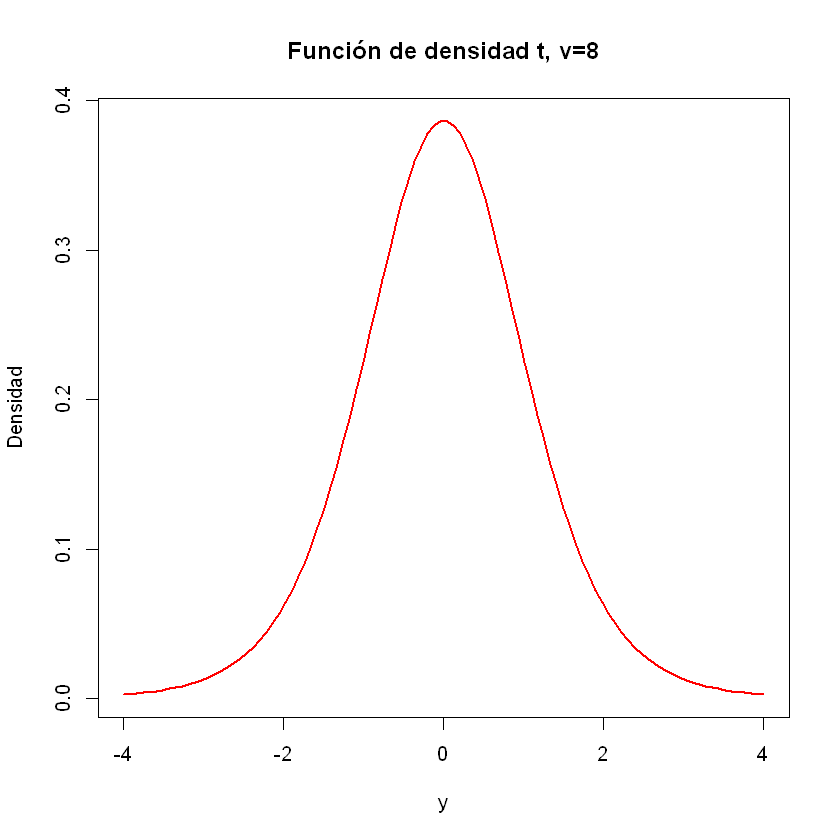

```r
plot(y, fy_t8, type="l",col="red",lwd=2,
     xlab="y",ylab="Densidad",
     main= "Función de densidad t, v=8")
```

La distribución $t$ también es simétrica y tiene forma de campana, sin embargo las colas de la distribución son más largas que la distribución normal. A medida que los grados de libertad $v=n-1$ aumentan (el número de datos es grande), la distribución $t$ converge con la distribución normal.

Gráficamente, compararemos la distribución normal estándar con la distribución $t$ con distintos grados de libertad. Observamos que con 30 grados de libertad, la distribución $t$ se asemeja bastante a la distribución normal estándar.

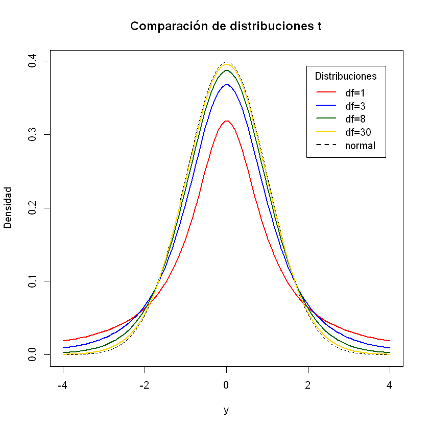

```r
# Secuencia
y  = seq(-4, 4, length=100)

# Distribuciones t con diferentes grados de libertad
fy_t1  = dt(x=y,  df=1)
fy_t3  = dt(x=y,  df=3)
fy_t8  = dt(x=y,  df=8)
fy_t30 = dt(x=y,  df=30)

# Distribución normal estandar
fy_n   = dnorm(x=y, mean=0, sd=1 )

# Plot distribución normal estandar
plot(y, fy_n, type="l", lty=2, xlab="y",
  ylab="Densidad", main="Comparación de distribuciones t")

# Incluir distribuciones t
lines(y, fy_t1, lwd=2, col="red")
lines(y, fy_t3, lwd=2, col="blue")
lines(y, fy_t8, lwd=2, col="darkgreen")
lines(y, fy_t30,lwd=2, col="gold")

# Leyenda del gráfico
etiquetas = c("df=1", "df=3", "df=8", "df=30", "normal")

legend("topright", inset=0.05, title="Distribuciones",
      legend=etiquetas, lwd=2, lty=c(1, 1, 1, 1, 2),
      col= c("red", "blue", "darkgreen", "gold", "black"))
```

Las funciones de dsitribución, cuantiles y generación de números aleatorios están también disponibles para esta distribución sin embargo, no hacen parte de este taller. Para más información consultar la ayuda de las funciones `pt`, `qt` y `rt`.